# Regression, Variable Selection, and Partial Least Squares

This lab uses a case study in chemistry to highlight key concepts in regression modeling. There are several questions embedded throughout the lab that will assume knowledge of the `caret` package, principle components analysis (PCA), and multiple linear regression. The lab will build knowledge and intution in data exploration and pre-processing, variable selection, principle components regression, partial least squares regression, and LASSO regression.

### Case Study - Drug Solubility

Chemical compounds, such as drugs, can be represented through chemical formulas describing their atomic components. For example, the popular drug aspirin contains nine carbon, eight hydrogen, and four oxygen atoms held together by various different chemical bonds. Using the chemical configuration, certain additional measures, such as molecular weight, surface area, or polarity, can be derived. However, there are many useful attributes that cannot be derived analytically, and their measurement typically requires careful labratory experiments.

One such attribute (that cannot be determined analytically) is a compound’s *solubility*, or how it behaves in a liquid solution. Solubility is important because it determines whether a drug can be given orally or needs to be administered via injection. The case study in this lab will explore modeling the solubility of chemical compounds using analytically derived variables.

Our case study is based upon research done by [Teko et al. (2001)](https://pubs.acs.org/doi/abs/10.1021/ci000392t) and [Huuskonen (2000)](https://pubs.acs.org/doi/10.1021/ci9901338), and borrows from the text [Applied Predictive Modeling](http://appliedpredictivemodeling.com/) by Max Kuhn and Kjell Johnson. The goal is to model the solubility of a compound using descriptors of its chemical structure. The idea is to use the model to screen compounds, some of which might not yet exist, for diserable properties. In general, this type of study investigates the quantitative structure-activity relationship (QSAR), and QSAR modeling is becoming increasingly prevalent in many areas of chemistry.

### Data Exploration and Pre-processing

The first step in most modeling building applications is to reserve a portion of the data for the test set. Recall that we use the test set only at the very end of the model building process, it allows us to get an unbiased assessment of how successful the model will be on new data. This is necessary because everything we do (ranging from data visualization to variable selection to model choice) using the training data induces the possibility of overfitting.

```r
library(caret)
#install.packages("AppliedPredictiveModeling")
library(AppliedPredictiveModeling)

data(solubility)
X <- rbind(solTestX, solTrainX)
y <- c(solTestY, solTrainY)
data <- data.frame(Solubility = y, X)

set.seed(1234)
test.id <- sample(1:nrow(X), size = .2*nrow(X)) ## Randomly choose 20% of rows for test set

test.data <- data[test.id,]  ## Subset to include rows designated to test set
train.data <- data[-test.id,]  ## Exclude rows designated to test set
```

After partitioning the data we can use the training data to begin to understand the predictor variables and how they relate with the outcome variable “Solubility”.

```r
head(train.data)
```

These data contain: - 208 binary variables that indicate the presence/absence of a specific chemical substructure - 16 count variables that indicate number of bonds or atoms of a specific type - 4 continuous variables indicating analytically derived characteristics like molecular weight or surface area - The outcome, solubility, which is measured on the log-scale

Because the overall number of predictors is moderate-to-high, we should be interested in variable selection, and/or dimension reduction. The first thing we should do is check for highly correlated predictors. Correlation is questionably defined for binary variables, so we will focus on the 20 count/continuous variables:

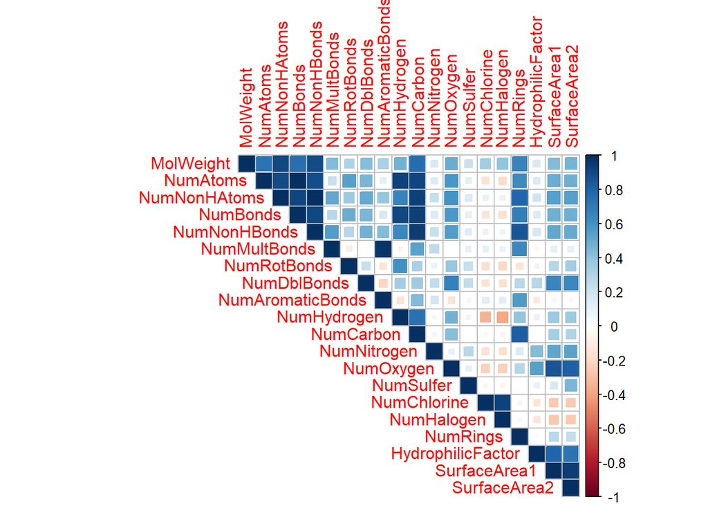

```r
## Only show the 20 analytic vars
#install.packages("corrplot")
library(corrplot)  ## A library for visualizing correlations
cor.matrix <- cor(train.data[,210:ncol(train.data)])  ## Find pairwise correlation matrix
corrplot(cor.matrix, type = "upper", method = "square") ## Plot the corr matrix
```

**Question 1**: Based upon the correlation matrix plot, provide an argument for reducing the dimension of these 20 variables. Then use PCA and the `fviz_screeplot` function to find a lower dimensional set of variables that retains at least 90% of the variation in these 20 variables. Be sure to use the argument `scale = TRUE`. Many components will you use?

**Question 2**: Try to interpret the first two components using `fviz_contrib` (with the argument `choice = "var"`) to help identify the most important contributing variables.

Continuing our analysis, we’ll use 8 variables derived from PCA as a lower dimensional representation of the original 20 variables. The scores for each component for each observation are stored in `x` within the object created by `prcomp`:

```r
P <- prcomp(train.data[,210:ncol(train.data)], scale = TRUE)
#head(P$x)
```

For clarity, we’ll setup a new training data object using only these 8 derived variables (and the outcome variable Solubility):

```r
train.data2 <- data.frame(Solubility = train.data$Solubility, P$x[,1:8])
```

### Relationships with the outcome

PCA (by design) ignores the outcome variable; consequently, there is no garauntee that each (or any) component is predictive of solubility. We should explore this graphically:

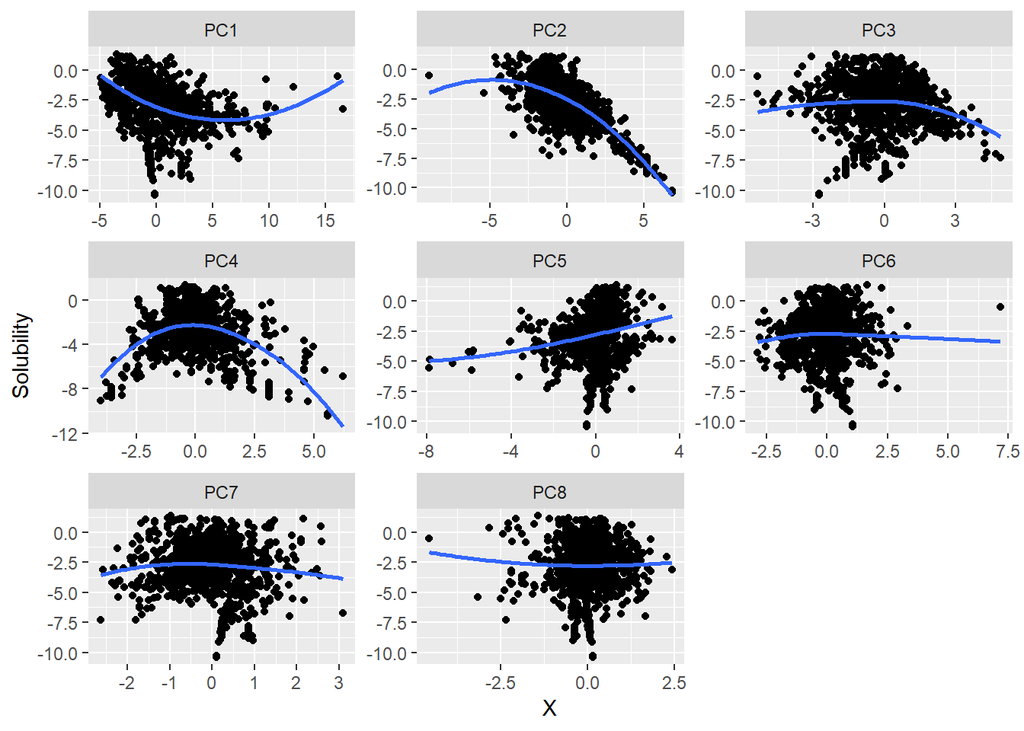

```r
library(tidyr)
## Tidy these data for plotting with ggplot
plot.df <- gather(train.data2, key = "Component", value = "X", 2:9)

ggplot(plot.df, aes(x = X, y = Solubility)) + geom_point() +
  geom_smooth(method = "loess", se = FALSE, span = 2) +  ## span alters the smoothness
  facet_wrap( ~ Component, scales = "free")
```

Interpretting this plot, we see that some of the components appear to be associated with solubility, while others don’t seem to be very predictive. We also see that fourth component might have a non-linear relationship with solubility. Typically, real non-linear relationships occur for an identifiable reason, so we should try to interpret this component:

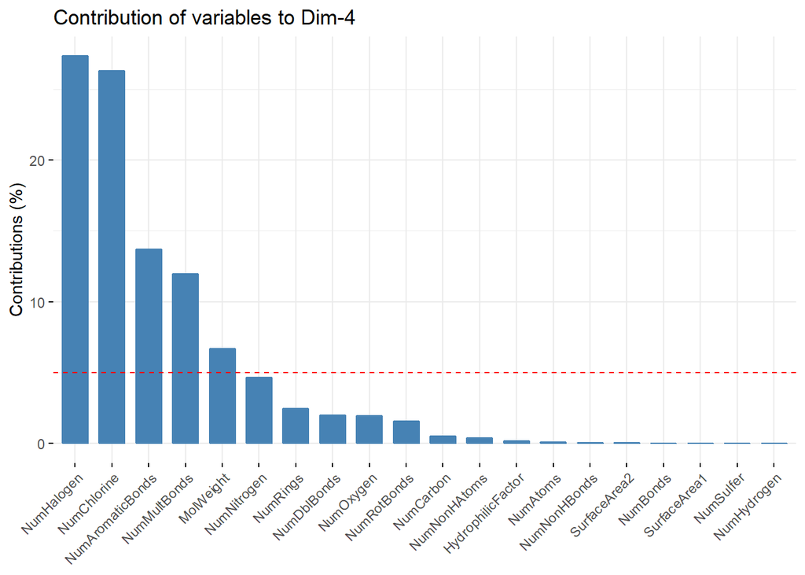

```r
fviz_contrib(P, choice = "var", axes = 4)
```

```r
P$rotation[,4]
```

```
##         MolWeight          NumAtoms      NumNonHAtoms          NumBonds
##      0.2584510545      0.0315405601      0.0623818844      0.0146473635
##      NumNonHBonds      NumMultBonds       NumRotBonds       NumDblBonds
##      0.0266645116     -0.3458979451      0.1256610469      0.1420161837
##  NumAromaticBonds       NumHydrogen         NumCarbon       NumNitrogen
##     -0.3703608707     -0.0002358333     -0.0729175467     -0.2157567694
##         NumOxygen         NumSulfer       NumChlorine        NumHalogen
##      0.1394703466      0.0019996931      0.5127105621      0.5229855536
##          NumRings HydrophilicFactor      SurfaceArea1      SurfaceArea2
##     -0.1569204616      0.0404384449      0.0135100957      0.0216224609
```

A compound will have high score in this component if it has a lot of halogen/cholrine atoms, but not many “Mult” or “Aromatic” bonds. Similarly, it will have a low score in this component if it has few halogen/cholrine atoms and a lot of “Mult” or “Aromatic” bonds. Both high and low scores seem to correspond with low solubility.

If you were actually working on this model you might want to consult with a chemist regarding this interpretation, since it implies a quadratic effect should be used when including this component in the model. All of the other component’s relationships with solubility appear to be roughly linear (we shouldn’t worry too much about the points near the edges of each plot that are clearly curving loess trendline)

## Model Building

An advantage of using `caret` for model building is the common formula syntax that is compatible with many types of models. In this syntax, the outcome variable is specified first and is seperated from predictor variables by the ~ character. Next predictor variables (or functions of them!) are specified, separated by + characters.

```r
## We will evaluate models using repeated cross validation
fit.control = trainControl(method = "repeatedcv", number = 5, repeats = 10)


## Find original vars most correlated with solubility
cors <- cor(train.data[,c(1,210:ncol(train.data))])
cors[,1]
```

```
##        Solubility         MolWeight          NumAtoms      NumNonHAtoms
##       1.000000000      -0.628474442      -0.385787758      -0.542849815
##          NumBonds      NumNonHBonds      NumMultBonds       NumRotBonds
##      -0.410300151      -0.554188802      -0.530108708      -0.118688770
##       NumDblBonds  NumAromaticBonds       NumHydrogen         NumCarbon
##       0.009796097      -0.518914174      -0.187763520      -0.579139809
##       NumNitrogen         NumOxygen         NumSulfer       NumChlorine
##       0.143343548       0.116052266      -0.084080893      -0.503666138
##        NumHalogen          NumRings HydrophilicFactor      SurfaceArea1
##      -0.492114144      -0.513914241       0.301403694       0.196919572
##      SurfaceArea2
##       0.148005281
```

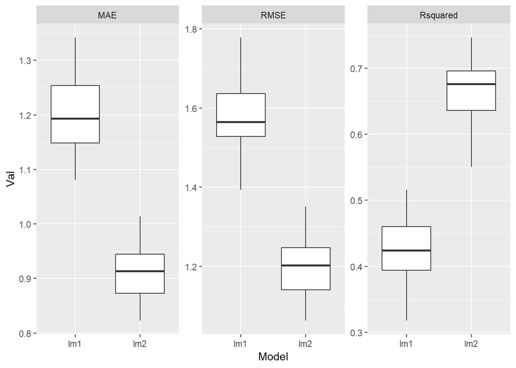

```r
## Specify a model using the two most correlated vars
model1 <- formula(Solubility ~ MolWeight + NumCarbon)

## Fit model1
set.seed(15)
fit.lm1 <- train(model1, data = train.data, method = "lm", trControl = fit.control)

## Model using the first two principle components
model2 <- formula(Solubility ~ PC1 + PC2)

set.seed(15)
fit.lm2 <- train(model2, data = train.data2, method = "lm", trControl = fit.control)

## Compare these two models
library(tidyr)
resamps <- resamples(list(lm1 = fit.lm1, lm2 = fit.lm2))
resamps2 <- gather(resamps$values, key = "Var", value = "Val", 2:ncol(resamps$values))
resamps2 <- separate(resamps2, col = "Var", into = c("Model", "Metric"), sep = "~")

ggplot(resamps2, aes(x = Model, y = Val)) + geom_boxplot() + facet_wrap(~ Metric, scales = "free")
```

**Question 3**: Based upon the results above which model is superior, the linear regression model that uses the two variables which were most correlated with `Solubility`, or the linear regression model that uses the first two principle components?

Neither of these models is likely to be optimal, the general workflow we should use is to add a predictor/group of predictors (or modify the form of an existing predictor), then use `caret` to determine if the change improves out-of-sample prediction error. The idea is to slowly increase the complexity of the model until we strike an ideal balance between performance and interpretability for our goals.

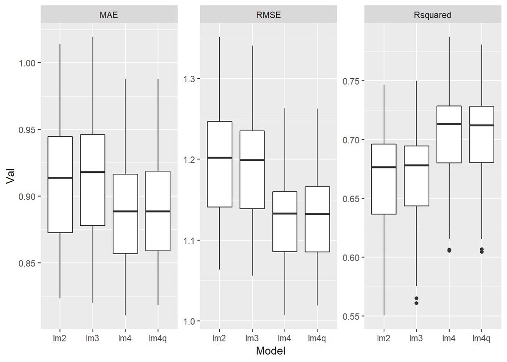

```r
## Some additional models:
model3 <- formula(Solubility ~ PC1 + PC2 + PC3)
model4 <- formula(Solubility ~ PC1 + PC2 + PC3 + PC4)
## The poly function can be used to add non-linear effects
model4q <- formula(Solubility ~ PC1 + PC2 + PC3 + poly(PC4, degree = 2))


set.seed(15)
fit.lm3 <- train(model3, data = train.data2, method = "lm", trControl = fit.control)
set.seed(15)
fit.lm4 <- train(model4, data = train.data2, method = "lm", trControl = fit.control)
set.seed(15)
fit.lm4q <- train(model4q, data = train.data2, method = "lm", trControl = fit.control)

## Compare these new models
resamps <- resamples(list(lm2 = fit.lm2, lm3 = fit.lm3, lm4 = fit.lm4, lm4q = fit.lm4q))
resamps2 <- gather(resamps$values, key = "Var", value = "Val", 2:ncol(resamps$values))
resamps2 <- separate(resamps2, col = "Var", into = c("Model", "Metric"), sep = "~")

ggplot(resamps2, aes(x = Model, y = Val)) + geom_boxplot() + facet_wrap(~ Metric, scales = "free")
```

**Question 4**: Based upon the modeling results displayed above, which model offers the performance? Also, is there an advantage in using a quadratic effect for the fourth principle component?

We shouldn’t stop at four principle components, we’ll check a few more:

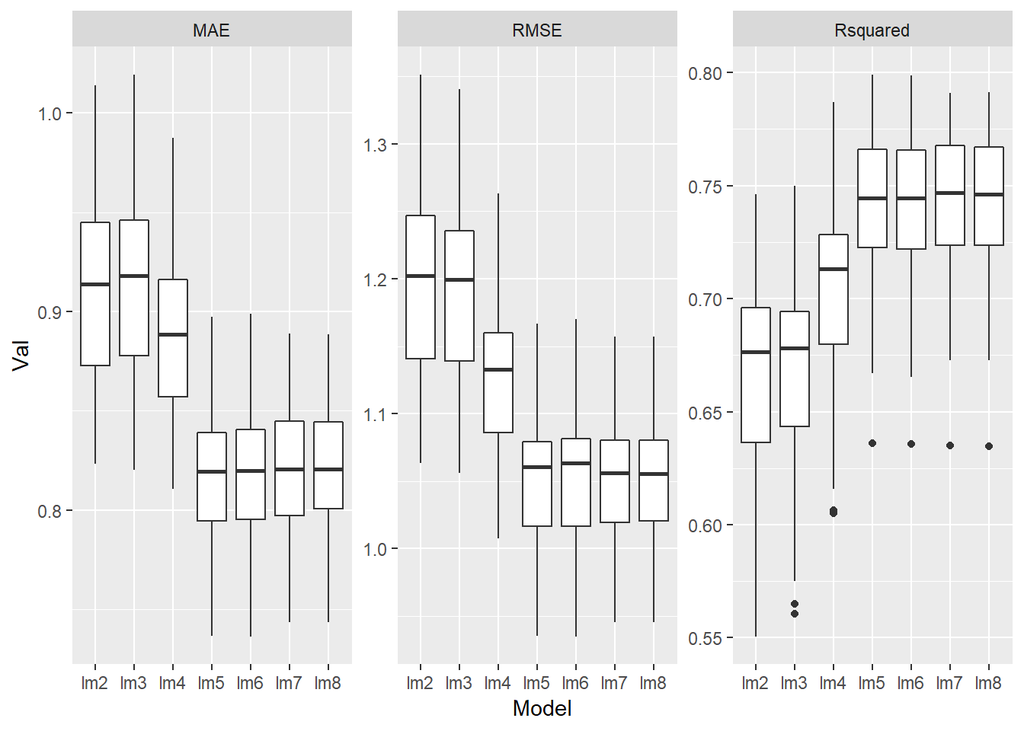

```r
## Let's try a few more models
model5 <- formula(Solubility ~ PC1 + PC2 + PC3 + PC4 + PC5)
model6 <- formula(Solubility ~ PC1 + PC2 + PC3 + PC4 + PC5 + PC6)
model7 <- formula(Solubility ~ PC1 + PC2 + PC3 + PC4 + PC5 + PC6 + PC7)
model8 <- formula(Solubility ~ PC1 + PC2 + PC3 + PC4 + PC5 + PC6 + PC7 + PC8)


set.seed(15)
fit.lm5 <- train(model5, data = train.data2, method = "lm", trControl = fit.control)
set.seed(15)
fit.lm6 <- train(model6, data = train.data2, method = "lm", trControl = fit.control)
set.seed(15)
fit.lm7 <- train(model7, data = train.data2, method = "lm", trControl = fit.control)
set.seed(15)
fit.lm8 <- train(model8, data = train.data2, method = "lm", trControl = fit.control)


## Compare these new models
resamps <- resamples(list(lm2 = fit.lm2, lm3 = fit.lm3, lm4 = fit.lm4, lm5 = fit.lm5,
                          lm6 = fit.lm6, lm7 = fit.lm7, lm8 = fit.lm8))
resamps2 <- gather(resamps$values, key = "Var", value = "Val", 2:ncol(resamps$values))
resamps2 <- separate(resamps2, col = "Var", into = c("Model", "Metric"), sep = "~")

ggplot(resamps2, aes(x = Model, y = Val)) + geom_boxplot() + facet_wrap(~ Metric, scales = "free")
```

This suggests the model using the first 5 principle components is the most sensible choice. Let’s compare this with the models suggested by the best subsets and stepwise selection algorithms. We’ll explore applying these algorithms to both the original data and new variables derived using principle components.

```r
library(CAST)
## Note: best subsets takes a lot of time to run
best_subs <- bss(train.data2[,-1], train.data2$Solubility, method = "lm", trControl = fit.control, verbose = FALSE, seed = 15)

best_subs$perf_all[order(best_subs$perf_all$RMSE)[1:6],]
```

```
##     var1 var2 var3 var4 var5 var6 var7 var8     RMSE          SE nvar
## 160  PC1  PC2  PC3  PC4  PC5  PC7 <NA> <NA> 1.047948 0.006644526    6
## 33   PC1  PC2  PC3  PC4  PC5  PC7  PC8 <NA> 1.048886 0.006639629    7
## 128  PC1  PC2  PC3  PC4  PC5  PC6  PC7 <NA> 1.049174 0.006650362    7
## 1    PC1  PC2  PC3  PC4  PC5  PC6  PC7  PC8 1.050149 0.006642596    8
## 222  PC1  PC2  PC3  PC4  PC5 <NA> <NA> <NA> 1.051467 0.007040616    5
## 97   PC1  PC2  PC3  PC4  PC5  PC8 <NA> <NA> 1.052361 0.007034444    6
```

```r
## How to evaluate recursive feature elimination
ctrl <- rfeControl(functions = lmFuncs, method = "repeatedcv", number = 5, repeats = 10, verbose = FALSE)

## Do the backward elimination
backward_subs <- rfe(train.data2[,-1], train.data2$Solubility,  rfeControl = ctrl, seed = 15, sizes = 2:8)
backward_subs
```

```
##
## Recursive feature selection
##
## Outer resampling method: Cross-Validated (5 fold, repeated 10 times)
##
## Resampling performance over subset size:
##
##  Variables  RMSE Rsquared    MAE  RMSESD RsquaredSD   MAESD Selected
##          2 1.355   0.5708 1.0741 0.05595    0.05061 0.04460
##          3 1.299   0.6047 1.0357 0.04497    0.04313 0.04251
##          4 1.059   0.7375 0.8198 0.05285    0.03097 0.04147
##          5 1.056   0.7391 0.8230 0.05293    0.03002 0.04176
##          6 1.047   0.7435 0.8182 0.05243    0.02970 0.04036        *
##          7 1.049   0.7427 0.8195 0.05202    0.02957 0.04027
##          8 1.050   0.7423 0.8202 0.05166    0.02940 0.03997
##
## The top 5 variables (out of 6):
##    PC2, PC5, PC4, PC1, PC7
```

```r
backward_subs$fit
```

```
##
## Call:
## lm(formula = y ~ ., data = tmp)
##
## Coefficients:
## (Intercept)          PC2          PC5          PC4          PC1
##     -2.7607      -0.7910       0.3798      -0.2891      -0.2532
##         PC7          PC3
##     -0.1298      -0.0939
```

Best subsets and recursive feature elimination both favor the same model, one with PC1, PC2, PC3, PC4, PC5, and PC7. These results are pretty similar to what we saw selecting variables manually.

We also might consider applying these variable selection algorithms to the orignal variables (rather than the derived principle components); however, this causes some problems:

```r
## This produces many warning messages!
backward_subs_original <- rfe(train.data[,210:ncol(train.data)], train.data$Solubility, rfeControl = ctrl, seed = 15)
```

Several of the original variables are linear combinations of the others. Principle components naturally accomodates this, but for regression it is problematic and results in untrustworthy models. We can use the `FindLinearCombos` function in the `caret` package to help us out:

```r
lin.coms <- findLinearCombos(train.data[,210:ncol(train.data)])
lin.coms$linearCombos
```

```
## [[1]]
## [1] 5 2 3 4
##
## [[2]]
## [1] 10  2  3
```

Very clearly, variables 2 through 5 are not linearly independent, which makes sense given that the total number of atoms is a function of the number of nitrogen, carbon, etc. We should remove variables so that all columns of the data matrix are linearly independent. By further inspecting the variables, it seems like “NumBonds”, “NumNonHBonds”, “NumAtoms”, and “NumNonHAtoms” are likely to be functions of other variables and should be removed:

```r
to.remove <- which(names(train.data[,210:ncol(train.data)]) %in% c("NumAtoms", "NumBonds", "NumNonHAtoms", "NumNonHBonds"))
new.train.X <- train.data[,210:ncol(train.data)]
new.train.X <- new.train.X[,-to.remove]
findLinearCombos(new.train.X)  ## Check if any linear combos remain
```

```
## $linearCombos
## list()
##
## $remove
## NULL
```

Now we should be apply to apply recursive feature elimination without problems:

```r
backward_subs_original <- rfe(new.train.X, train.data$Solubility, rfeControl = ctrl, seed = 15, sizes = 2:16)
backward_subs_original
```

```
##
## Recursive feature selection
##
## Outer resampling method: Cross-Validated (5 fold, repeated 10 times)
##
## Resampling performance over subset size:
##
##  Variables   RMSE Rsquared    MAE  RMSESD RsquaredSD   MAESD Selected
##          2 1.7525   0.2829 1.3876 0.07317    0.04920 0.05764
##          3 1.7494   0.2850 1.3830 0.07487    0.05192 0.05998
##          4 1.6692   0.3490 1.3211 0.06877    0.05184 0.05948
##          5 1.5957   0.4074 1.2548 0.08815    0.05675 0.06192
##          6 1.5751   0.4219 1.2323 0.09565    0.06387 0.07759
##          7 1.4887   0.4829 1.1458 0.08471    0.05277 0.06329
##          8 1.3093   0.5989 1.0090 0.08368    0.04638 0.06064
##          9 1.0183   0.7568 0.8009 0.05508    0.03053 0.04179
##         10 1.0128   0.7593 0.7956 0.05703    0.03148 0.04338
##         11 0.9939   0.7684 0.7858 0.05147    0.02825 0.03911
##         12 0.9852   0.7724 0.7774 0.05483    0.02900 0.04122
##         13 0.9771   0.7760 0.7722 0.05425    0.02924 0.04112
##         14 0.9679   0.7803 0.7670 0.05215    0.02860 0.03850
##         15 0.9578   0.7847 0.7549 0.05232    0.02864 0.03864
##         16 0.9390   0.7930 0.7329 0.05550    0.03011 0.04034        *
##
## The top 5 variables (out of 16):
##    NumSulfer, NumMultBonds, NumAromaticBonds, NumNitrogen, NumOxygen
```

**Question 5**: Of all the models considered so far, which do you prefer? Create a plot that shows the top three models side-by-side.

## Partial Least Squares (PLS)

Notice how the cross-validated RMSE is substantially lower for many models than it was when we did principle components regression. This is not necessarily unusual, principle components analysis is an unsupervised learning approach, so it is effective in dimension reduction, but there is no garauntee that any of the new dimensions will be associated with the response.

PCA blindly chases variability with no consideration of the outcome variable, so you might expect that a more targeted approach which considers the outcome variability will be more effective for supervised learning problems. One such method is [Partial Least Squares (PLS)](https://www.casact.org/pubs/dpp/dpp08/08dpp76.pdf).

PLS is similar to PCA in the sense that it constructs new derived dimensions in $X$, but it operates such that covariance between $X$ and $Y$ is maximized for each newly derived dimension. Thus, the first component of PLS is a linear combination of the original variables *that is most strongly related with* $Y$.

```r
set.seed(15)
pls.fit <- train(Solubility ~ .,  data = train.data[,c(1,210:ncol(train.data))], method = "pls", trControl = fit.control, tuneGrid = data.frame(ncomp = 1:20))
pls.fit
```

```
## Partial Least Squares
##
## 1014 samples
##   20 predictor
##
## No pre-processing
## Resampling: Cross-Validated (5 fold, repeated 10 times)
## Summary of sample sizes: 812, 811, 812, 810, 811, 813, ...
## Resampling results across tuning parameters:
##
##   ncomp  RMSE          Rsquared   MAE
##    1     1.550330e+00  0.4426925  1.170633e+00
##    2     1.191208e+00  0.6691320  9.352446e-01
##    3     1.101970e+00  0.7164346  8.532216e-01
##    4     1.088074e+00  0.7231585  8.409514e-01
##    5     1.066375e+00  0.7339962  8.245391e-01
##    6     1.033949e+00  0.7500299  7.974753e-01
##    7     1.008583e+00  0.7621118  7.795658e-01
##    8     9.712156e-01  0.7794245  7.582987e-01
##    9     9.644149e-01  0.7825186  7.506145e-01
##   10     9.558243e-01  0.7865601  7.450759e-01
##   11     9.526745e-01  0.7878583  7.452947e-01
##   12     9.503084e-01  0.7889196  7.458654e-01
##   13     9.478888e-01  0.7901273  7.441893e-01
##   14     9.409136e-01  0.7931063  7.375683e-01
##   15     9.394829e-01  0.7937249  7.348799e-01
##   16     9.367423e-01  0.7949228  7.316322e-01
##   17     9.364424e-01  0.7950754  7.318705e-01
##   18     2.548877e+13  0.4291598  2.074847e+13
##   19     6.145183e+13  0.2049947  4.805330e+13
##   20     1.246062e+14  0.2095853  9.702521e+13
##
## RMSE was used to select the optimal model using the smallest value.
## The final value used for the model was ncomp = 17.
```

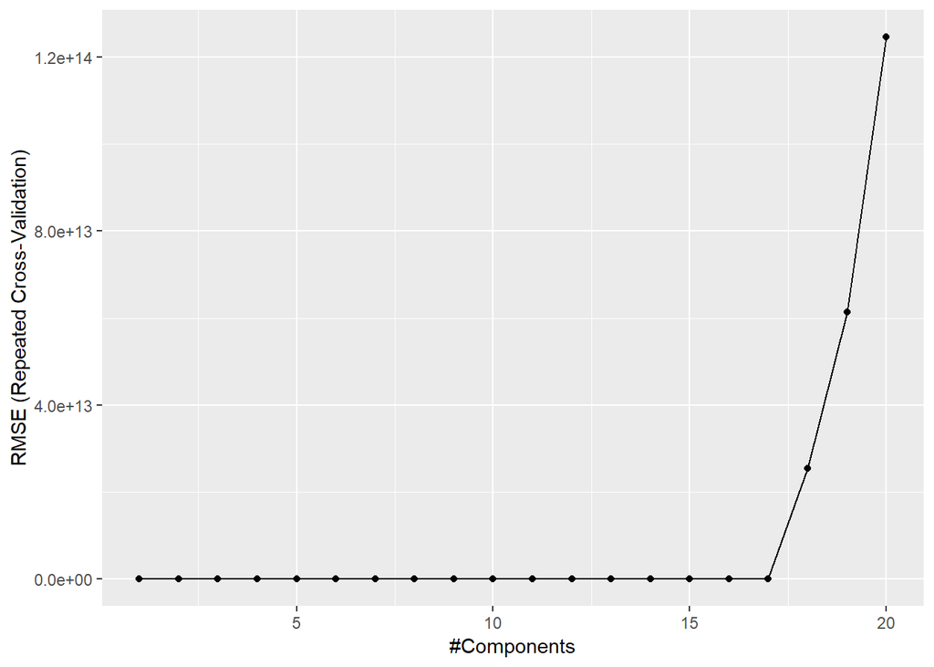

```r
ggplot(pls.fit)
```

**Question 6**: Thinking about the 20 original variables we used as predictors in PLS, why does the RSME skyrocket when more than 17 components are used? (Hint: think about the challenges we had applying variable selection algorithms to these 20 variables in the last section)

We can use the `varImp` function to gauge which variables are most influential in the “best” PLS model (best is determined by the lowest RMSE):

```r
varImp(pls.fit)
```

```
## pls variable importance
##
##                   Overall
## NumMultBonds      100.000
## MolWeight          97.570
## NumChlorine        86.748
## NumOxygen          81.495
## NumAromaticBonds   69.860
## NumCarbon          68.246
## SurfaceArea1       65.018
## SurfaceArea2       61.521
## NumNonHAtoms       50.229
## NumHalogen         47.978
## HydrophilicFactor  37.829
## NumRotBonds        36.242
## NumNitrogen        32.875
## NumSulfer          32.675
## NumDblBonds        32.321
## NumNonHBonds       28.199
## NumHydrogen        20.422
## NumRings            5.814
## NumBonds            1.680
## NumAtoms            0.000
```

```r
#pls.fit$finalModel$loadings # See the loadings for each component
```

**Question 7**: Compare the PLS models (contained in `pls.fit`) with the previous best models (which you plotted in Question 5). Update your plot (created in Question 5) to include one of these PLS models.

## Least Absolute Shrinkage and Selection Operator (LASSO)

So far we’ve neglected the 208 binary structure variables, which could potentially improve our predictions. There are too many of these variables to expect good results from foward/backward variable selection, and PCA/PLS aren’t designed for binary variables (though there is some debate on whether they could be applied). An efficient and powerful a alternative method, the LASSO, is well-suited for this situation.

While the LASSO is implemented in `caret`, the `ncvreg` package itself offers a better implementation of cross validation:

```r
library(ncvreg)
set.seed(15)
cv.fit <- cv.ncvreg(X = train.data[,-1], y = train.data$Solubility, penalty = "lasso")
summary(cv.fit)
```

```
## lasso-penalized linear regression with n=1014, p=228
## At minimum cross-validation error (lambda=0.0069):
## -------------------------------------------------
##   Nonzero coefficients: 133
##   Cross-validation error (deviance): 0.47
##   R-squared: 0.89
##   Signal-to-noise ratio: 8.03
##   Scale estimate (sigma): 0.687
```

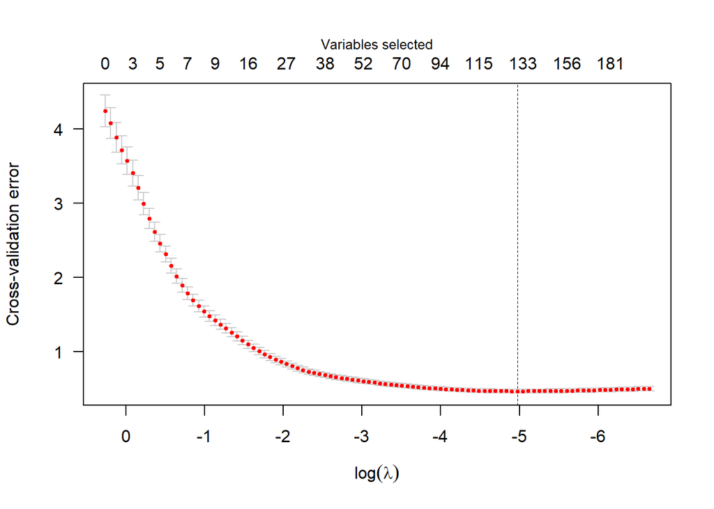

```r
plot(cv.fit)
```

We can see that the cross-validated $R^2$ goes up by about 10% using this model (which incorperates the 208 binary structure features). The cross-validation error reported by `ncvreg` is not square-rooted, so for this LASSO model $RMSE = \sqrt{0.47} = 0.686$.

In any LASSO model only a subset of the available predictors are active (make a non-zero contribution to the model). We can see the set of selected features (and their regression coefficients) using the commands below:

```r
## Within cv.fit is the fitted lasso model (fit)
## Within the fitted model is beta, a matrix of regression coefficients for each lambda
## We want only the column of beta corresponding to the lambda that minimizes CV RSME
all_coefs <- cv.fit$fit$beta[,cv.fit$fit$lambda == cv.fit$lambda.min]
all_coefs[all_coefs != 0]
```

**Question 8**: (**THIS QUESTION WILL NOT BE GRADED, IT TAKES TOO LONG FOR ffs to RUN**) Use forward feature selection (implemented in the `ffs` function, see the slides for an example) on the data (including the 208 binary structure features) using `method = "lm"`. How does this model compare to the LASSO model? (compare their predictive performance and selected variables)

## Conclusions

In this application we saw that using a reduced set of derived dimensions offered an advantage over using subsets of the original variables, but only if the construction of those dimensions took the outcome variable into consideration (partial least squares performed better than principle components regression). We then saw that the 208 binary features could aid prediction even further the appropriate method was used to perform feature selection.

The final step in this analysis would be to apply our selected model to the test data. This would be done using the `predict` function, and a would be a key determinant of how successful your chosen model is.